# Home Repair Tax Credit Program

Bingchu Chen

10/25/2020

```r
knitr::opts_chunk$set(message = FALSE, warning = FALSE)
```

```r
options(scipen=10000000)

library(tidyverse)
library(kableExtra)
library(caret)
library(knitr)
library(pscl)
library(plotROC)
library(pROC)
library(lubridate)
library(gridExtra)
library(forcats)
library(stargazer)
library(sjPlot)
library(sjmisc)
library(sjlabelled)
```

```r
palette5 <- c("#d24ae8","#f0b660","#981FAC","#f5614e","#00bafe")
palette4 <- c("#d24ae8","#f0b660","#981FAC","#f5614e")
palette2 <- c("#d24ae8","#f0b660")

root.dir = "https://raw.githubusercontent.com/urbanSpatial/Public-Policy-Analytics-Landing/master/DATA/"
source("https://raw.githubusercontent.com/urbanSpatial/Public-Policy-Analytics-Landing/master/functions.r")

housingsubsidy <- read.csv("E:/Upenn/CPLN508/tax_credits/Home-Repair-Tax-Credit-Program/housingSubsidy.csv") %>%

  rename(tookSubsidyNum = y_numeric,
         prevMktgOutcome = poutcome,
         tookSubsidy = y)
```

# Motivation

Department of Housing and Community Development (DHC)’s Home Repair Tax Credit Program is a program that help enhance the social good by offering those households in need credits to repair their homes. By doing so, the house value of these households as well as the surrounding houses will all go up due to the spillover effect. All these enhancement will lead to rise in the neighborhood aesthetics, safety, land development, economic activities and thus higher overall tax revenue in this area. The increased tax revenue can then be applied to generate more public good and further raise the social welfare. Given the great benefits that this program can bring to the society, DHC’s goal is to provide all the needed households with this tax credit. To better promote this program, marketing materials are distributed to attract these potential households, regardless of the costs that the DHC needs to pay.

# Data Visualization

The result of the prior campaign indicates that there are significantly fewer number of homeowners taking the subsidy credits than those not (Figure 1.1). This class imbalance can seriously affect out model performance, which will be further illustrated later in this memo.

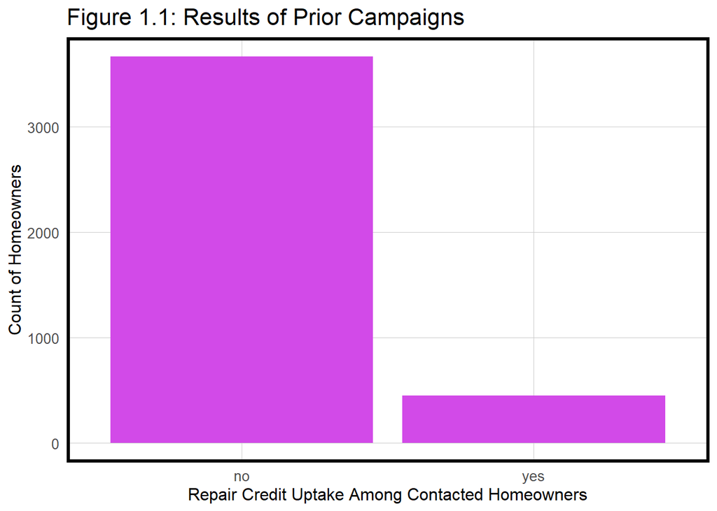

```r
ggplot(mutate(housingsubsidy, tookSubsidy = fct_infreq(tookSubsidy))) + geom_bar(aes(x = tookSubsidy), fill = "#d24ae8") +
  labs(title = "Figure 1.1: Results of Prior Campaigns", x = "Repair Credit Uptake Among Contacted Homeowners", y = "Count of Homeowners") +
  plotTheme()
```

Among all the features we have for prediction, for continuous variables, people are more likely to accept the subsidy when they are older, contacted for this campaign fewer times but much more frequently contacted before this campaign, had a sooner follow-up from a previous program, and are going through a time with high consumer confident index, and low inflation and unemployment rates at the campaign time.

For categorical variables, people are more likely to accept the subsidy when they use a cell phone instead of a telephone, have a university degree, have a administrative job, didn’t participate or successfully participated in the last campaign, have a mortgage, are married and are full-time residents in Philadelphia.

It’s interesting that people who spend more annually on housing repairs don’t have a higher tendency in participating in this tax credit program. This suggests that our current practice to attract potential house owners is not accurate enough and needs to be refined.

The features that contribute most to the distinction between house owners accepting the subsidy and owners not are unemployment and inflation rates, as well as the number of contacts before this campaign for continuous variables, and residency location, participation in previous campaign, device for contact, job and marital status for categorical variables.

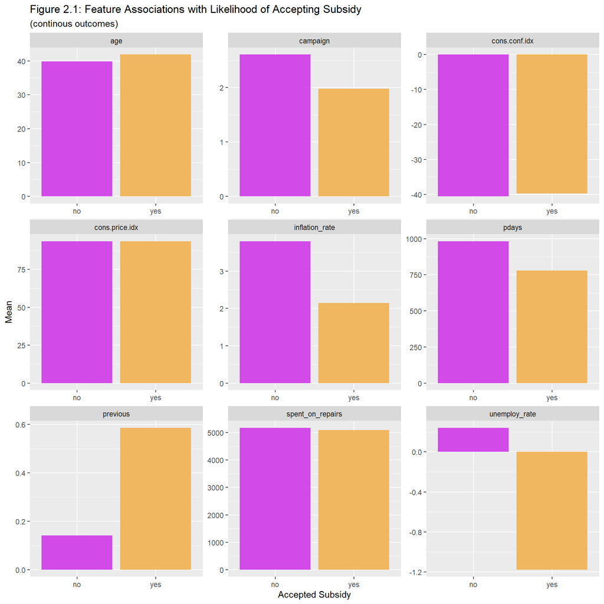

```r
#Continuous variables
housingsubsidy %>%
  dplyr::select(tookSubsidy, age, campaign, pdays, previous, spent_on_repairs, unemploy_rate, cons.price.idx, cons.conf.idx, inflation_rate) %>%
  gather(Variable, value, -tookSubsidy) %>%
    ggplot(aes(tookSubsidy, value, fill=tookSubsidy)) +
      geom_bar(position = "dodge", stat = "summary", fun = "mean") +
      facet_wrap(~Variable, scales = "free") +
      scale_fill_manual(values = palette2) +
      labs(x="Accepted Subsidy", y="Mean",
           title = "Figure 2.1: Feature Associations with Likelihood of Accepting Subsidy",
           subtitle = "(continous outcomes)") +
      theme(legend.position = "none")
```

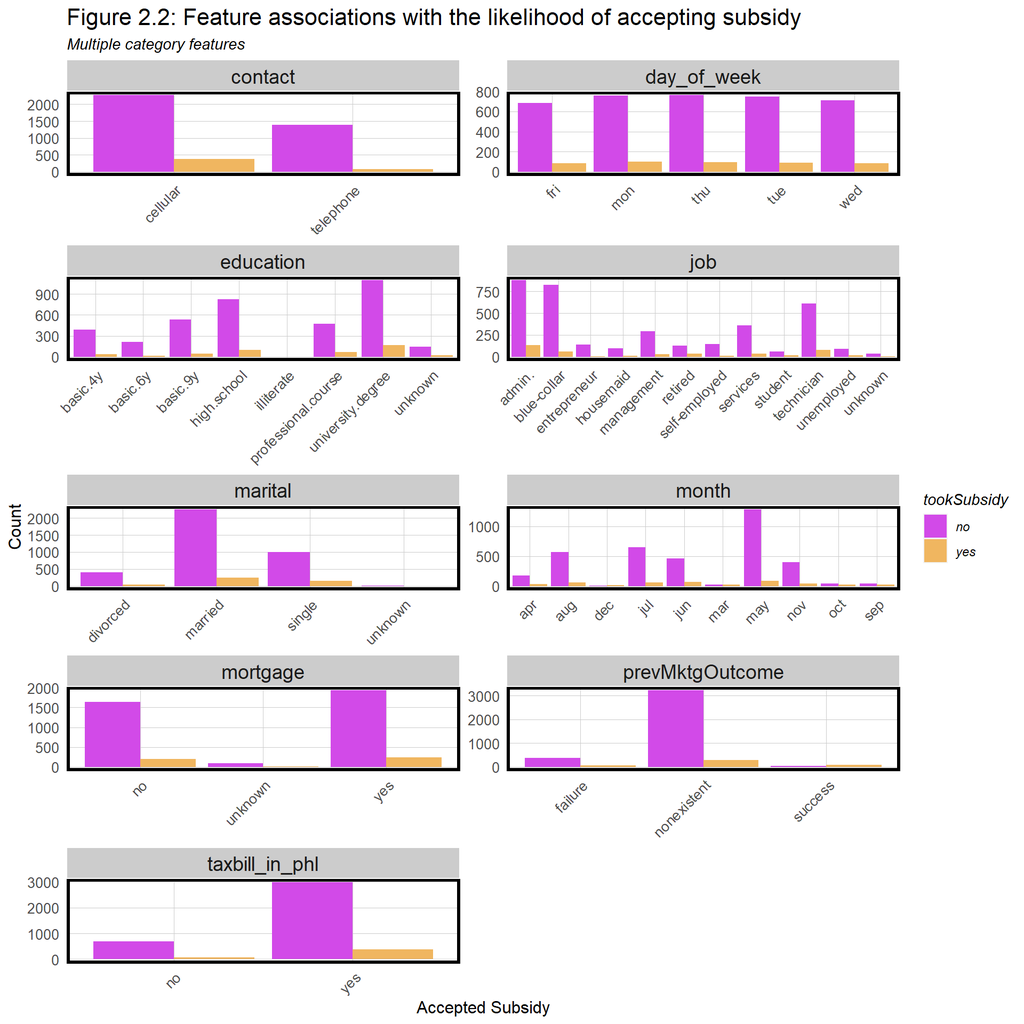

```r
#more than 2 categories
housingsubsidy %>%
  dplyr::select(tookSubsidy, job, marital, education, contact, month, day_of_week, prevMktgOutcome, mortgage, taxbill_in_phl) %>%
  gather(Variable, value, -tookSubsidy) %>%
  count(Variable, value, tookSubsidy) %>%
  ggplot(aes(value, n, fill = tookSubsidy)) +
    geom_bar(position = "dodge", stat="identity") +
    facet_wrap(~Variable, scales="free", ncol=2) +
    scale_fill_manual(values = palette2) +
    labs(x="Accepted Subsidy", y="Count",
         title = "Figure 2.2: Feature associations with the likelihood of accepting subsidy",
         subtitle = "Multiple category features") +
    plotTheme() + theme(axis.text.x = element_text(angle = 45, hjust = 1))
```

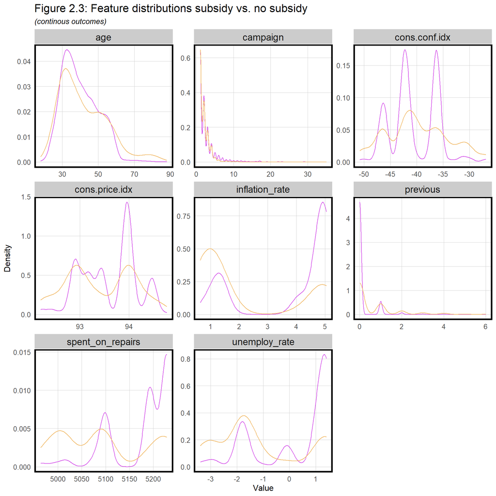

```r
##for continuous variables
housingsubsidy %>%
    dplyr::select(tookSubsidy, age, spent_on_repairs ,unemploy_rate , campaign, inflation_rate, previous, cons.price.idx, cons.conf.idx) %>%
    gather(Variable, value, -tookSubsidy) %>%
    ggplot() +
    geom_density(aes(value, color=tookSubsidy), fill = "transparent") +
    theme(legend.position = 'right') +
    facet_wrap(~Variable, scales = "free") +
    #scale_fill_manual(values = palette2) +
    scale_color_manual(labels = c('first', 'second'), values = c('#d24ae8','#f0b660'))+
    labs(title = "Figure 2.3: Feature distributions subsidy vs. no subsidy",
         subtitle = "(continous outcomes)", x = "Value", y = "Density") +
    theme(legend.position = "none") +
  plotTheme()
```

# Refining the Prediction Model

## Engineer new features

Six new features are added, including employment status, age group, education degree group, working industry, time from last contact and if contacted before.

The original job data generates the employment status (unemployed, retired, student, employed) and working industry two new features, based on the assumption that people who are out of job or are in certain industries earn less money or have less time for home repairing, thus are more in need of the tax credits.

The original data of age generates a new feature by being divided into groups (young adult, middle-aged adult and old adult), based on the assumption that people in certain stage of life are more in need of housing thus the maintenance of the housing.

The original education data generates the new feature of degree group, based on the assumption that people with lower than college degree are likely earn less and therefore are more in need of the subsidy.

Finally, we use contact information to generate two new features lastContact (never contacted, 1-2 weeks, 2-3 weeks and more than 3 weeks) and contactedBefore (yes or no), based on the assumption that people who are contacted before or more frequently contacted have a higher chance of accepting the subsidy because they are more aware of this program and are more likely to be convinced.

```r
housingsubsidy <-
  housingsubsidy %>%
  mutate(employStatus = case_when(job == "unemployed"  ~ "unemployed",
                                   job == "retired" ~ "retired",
                                  job == "student" ~ "student",
                                   TRUE  ~ "employed"),
         ageGroup = case_when(age >= 18 & age < 35 ~ "Young adult",
                                   age >= 35 & age < 65  ~ "Middle-aged adult",
                                   age >= 65  ~ "Old adult"),
         degreeGroup = case_when(education == "high.school" ~ "high school",
                                   education == "university.degree" ~ "bachelor's",
                                   education == "unknown" ~ "unknown",
                                  education == "illiterate" ~ "illiterate",
                                  TRUE ~ "Below high school"),
         industry = case_when(job == "blue-collar" | job == "technician" ~ "blue collar",
                              job == "services" | job == "housemaid" ~ "services",
                              job == "entrepreneur" | job == "self-employed" ~ "entrepreneur",
                              job == "admin." | job == "management" ~ "white collar",
                              TRUE ~ "Unknown"),
         lastContact = case_when(pdays == 999 ~ "never contacted",
                                 pdays < 7 ~ "Past week",
                                 pdays >= 7 & pdays < 14 ~ "1-2 Weeks",
                                 pdays >= 14 & pdays < 21 ~ "2-3 Weeks",
                               TRUE ~ "More than 3 Weeks"),
         contactedBefore = case_when(previous == 0 ~ "no",
                                  TRUE ~ "yes"))
```

## Building the model with new features

After we have all the new features added to the original data, we divide it into training set and testing set.

```r
set.seed(10)
trainIndex <- createDataPartition(housingsubsidy$tookSubsidy,
                                  y = paste(housingsubsidy$taxLien, housingsubsidy$degreeGroup, housingsubsidy$lastContact),
                                  p = .65,
                                  list = FALSE,
                                  times = 1)
housingsubsidyTrain <- housingsubsidy[ trainIndex,]
housingsubsidyTest  <- housingsubsidy[-trainIndex,]
```

The regression summaries for both the kitchen-sink model and the model with new features are shown in table 1. The latter one has a higher R square, suggesting that it outperforms in explaining the variance of our features.

```r
#include all to see the coefficients
reg0 <- glm(tookSubsidyNum ~ .,
                  data=housingsubsidyTrain %>%
                    dplyr::select(-X, -tookSubsidy), #delete all the NAs
                  family="binomial" (link="logit"))


#without engineered features, namely the kitchen sink
reg1 <- glm(tookSubsidyNum ~ .,
                  data=housingsubsidyTrain %>%
                    dplyr::select(-employStatus, -ageGroup, -degreeGroup, -industry, -lastContact, -contactedBefore, -X, -tookSubsidy),
                  family="binomial" (link="logit"))


#with engineered features
reg2 <- glm(tookSubsidyNum ~ .,
                  data=housingsubsidyTrain %>%
                    dplyr::select(-age, -job, -education, -pdays, -previous, -X, -tookSubsidy, -taxLien),
                  family="binomial" (link="logit"))


#with variables that explain the most based on reg1 and reg2
#reg3 <- glm(tookSubsidyNum ~ .,
#                  data=housingsubsidyTrain %>%
#                    dplyr::select(-X, -tookSubsidy, -industry, -degreeGroup, -employStatus,-contactedBefore, -taxLien),
#                  family="binomial" (link="logit"))


tab_model(reg1, reg2, show.se = TRUE, show.std = TRUE,
  col.order = c("p", "stat", "est", "std.se", "se", "std.est"), dv.labels = c("Kitchen-sink Model", "New-features Model"), p.style = "stars", title = "Table 1: Two regression models summary")
```

Table 1: Two regression models summary

Kitchen-sink Model

New-features Model

Predictors

Odds Ratios

standardized std. Error

std. Error

std. Beta

Odds Ratios

standardized std. Error

std. Error

std. Beta

(Intercept)

0.00

0.03

0.00

0.04

0.00

0.08

0.00

0.10

age

1.01

0.10

0.01

1.11

job [blue-collar]

0.78

0.22

0.22

0.78

job [entrepreneur]

0.50

0.28

0.28

0.50

job [housemaid]

1.07

0.48

0.48

1.07

job [management]

0.62

0.20

0.20

0.62

job [retired]

0.83

0.32

0.32

0.83

job [self-employed]

0.64

0.27

0.27

0.64

job [services]

0.86

0.26

0.26

0.86

job [student]

0.76

0.34

0.34

0.76

job [technician]

0.84

0.21

0.21

0.84

job [unemployed]

0.99

0.43

0.43

0.99

job [unknown]

1.10

0.82

0.82

1.10

marital [married]

1.51

0.42

0.42

1.51

1.48

0.41

0.41

1.48

marital [single]

1.73

0.55

0.55

1.73

1.61

0.50

0.50

1.61

marital [unknown]

0.00

0.00

0.00

0.00

0.00

0.00

0.00

0.00

education [basic.6y]

1.23

0.52

0.52

1.23

education [basic.9y]

1.42

0.47

0.47

1.42

education [high.school]

1.12

0.37

0.37

1.12

education [illiterate]

0.00

0.00

0.00

0.00

education  
[professional.course]

1.01

0.37

0.37

1.01

education  
[university.degree]

1.16

0.38

0.38

1.16

education [unknown]

0.93

0.41

0.41

0.93

taxLien [unknown]

0.94

0.21

0.21

0.94

taxLien [yes]

0.00

0.01

0.01

0.00

mortgage [unknown]

0.88

0.44

0.44

0.88

0.90

0.46

0.46

0.90

mortgage [yes]

0.85

0.13

0.13

0.85

0.87

0.13

0.13

0.87

taxbill_in_phl [yes]

0.97

0.19

0.19

0.97

0.99

0.20

0.20

0.99

contact [telephone]

0.41 **

0.12

0.12

0.41

0.42 **

0.12

0.12

0.42

month [aug]

1.37

0.61

0.61

1.37

1.49

0.66

0.66

1.49

month [dec]

3.29

2.28

2.28

3.29

3.27

2.27

2.27

3.27

month [jul]

1.08

0.42

0.42

1.08

1.22

0.47

0.47

1.22

month [jun]

0.91

0.44

0.44

0.91

0.92

0.44

0.44

0.92

month [mar]

9.18 ***

5.20

5.20

9.18

9.82 ***

5.60

5.60

9.82

month [may]

0.81

0.27

0.27

0.81

0.84

0.28

0.28

0.84

month [nov]

0.66

0.30

0.30

0.66

0.68

0.30

0.30

0.68

month [oct]

1.09

0.63

0.63

1.09

1.23

0.71

0.71

1.23

month [sep]

1.32

0.84

0.84

1.32

1.32

0.85

0.85

1.32

day_of_week [mon]

0.85

0.20

0.20

0.85

0.84

0.20

0.20

0.84

day_of_week [thu]

0.90

0.21

0.21

0.90

0.89

0.21

0.21

0.89

day_of_week [tue]

1.08

0.25

0.25

1.08

1.04

0.24

0.24

1.04

day_of_week [wed]

1.32

0.31

0.31

1.32

1.30

0.30

0.30

1.30

campaign

0.93

0.09

0.04

0.82

0.92

0.09

0.04

0.82

pdays

1.00

0.12

0.00

0.90

previous

1.14

0.11

0.21

1.07

prevMktgOutcome  
[nonexistent]

2.00 *

0.66

0.66

2.00

1.71 *

0.42

0.42

1.71

prevMktgOutcome [success]

3.44

2.31

2.31

3.44

1.95

1.42

1.42

1.95

unemploy_rate

0.25 **

0.09

0.12

0.12

0.25 **

0.09

0.12

0.11

cons.price.idx

6.88 *

1.55

6.04

3.06

7.40 *

1.62

6.48

3.19

cons.conf.idx

1.06

0.17

0.03

1.28

1.05

0.17

0.03

1.27

inflation_rate

1.27

1.21

0.58

1.51

1.28

1.23

0.59

1.54

spent_on_repairs

1.00

1.14

0.01

1.43

1.00

1.11

0.01

1.39

employStatus [retired]

0.76

0.59

0.59

0.76

employStatus [student]

0.55

0.45

0.45

0.55

employStatus [unemployed]

0.79

0.64

0.64

0.79

ageGroup [Old adult]

1.18

0.54

0.54

1.18

ageGroup [Young adult]

1.05

0.18

0.18

1.05

degreeGroup [Below high  
school]

1.01

0.21

0.21

1.01

degreeGroup [high school]

0.95

0.20

0.20

0.95

degreeGroup [illiterate]

0.00

0.00

0.00

0.00

degreeGroup [unknown]

0.94

0.35

0.35

0.94

industry [entrepreneur]

0.75

0.26

0.26

0.75

industry [services]

1.14

0.29

0.29

1.14

industry [Unknown]

1.51

1.08

1.08

1.51

industry [white collar]

1.14

0.24

0.24

1.14

lastContact2-3 Weeks

0.08 *

0.10

0.10

0.08

lastContact [More than 3  
Weeks]

896835.64

1305252636.01

1305252635.79

896835.64

lastContact [never  
contacted]

0.43

0.31

0.31

0.43

lastContact [Past week]

1.64

0.96

0.96

1.64

Observations

2689

2689

R<sup>2</sup> Tjur

0.234

0.240

- p<0.05 ** p<0.01 *** p<0.001

# Results

## Cross validate both models

```r
#4c: Cross validate both models; compare and interpret two facetted plots of ROC, Sensitivity and Specificity.

ctrl <- trainControl(method = "cv", number = 100, classProbs=TRUE, summaryFunction=twoClassSummary)

#kitchen sink
cvFit1 <- train(tookSubsidy ~ ., data = housingsubsidy %>%
                                   dplyr::select(-employStatus, -ageGroup, -degreeGroup, -industry, -lastContact, -contactedBefore, -X, -tookSubsidyNum),
                method="glm", family="binomial",
                metric="ROC", trControl = ctrl)

cvFit1
```

```
## Generalized Linear Model
##
## 4119 samples
##   19 predictor
##    2 classes: 'no', 'yes'
##
## No pre-processing
## Resampling: Cross-Validated (100 fold)
## Summary of sample sizes: 4077, 4078, 4077, 4078, 4078, 4077, ...
## Resampling results:
##
##   ROC        Sens       Spec
##   0.7689223  0.9803228  0.221
```

```r
#selected features
cvFit2 <- train(tookSubsidy ~ ., data = housingsubsidy %>%
                                   dplyr::select(-age, -job, -education, -pdays, -previous, -taxLien, -X, -tookSubsidyNum),
                method="glm", family="binomial",
                metric="ROC", trControl = ctrl)

cvFit2
```

```
## Generalized Linear Model
##
## 4119 samples
##   19 predictor
##    2 classes: 'no', 'yes'
##
## No pre-processing
## Resampling: Cross-Validated (100 fold)
## Summary of sample sizes: 4079, 4077, 4077, 4077, 4078, 4077, ...
## Resampling results:
##
##   ROC       Sens       Spec
##   0.770208  0.9817492  0.2245
```

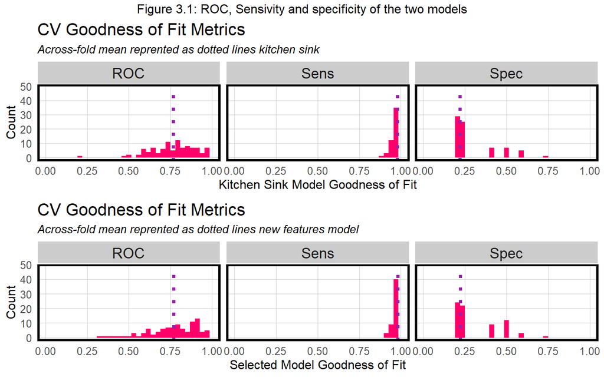

```r
#kitchen sink
f1<-
dplyr::select(cvFit1$resample, -Resample) %>%
  gather(metric, value) %>%
  left_join(gather(cvFit1$results[2:4], metric, mean)) %>%
  ggplot(aes(value)) +
    geom_histogram(bins=35, fill = "#FF006A") +
    facet_wrap(~metric) +
    geom_vline(aes(xintercept = mean), colour = "#981FAC", linetype = 3, size = 1.5) +
    scale_x_continuous(limits = c(0, 1)) +
    labs(x="Kitchen Sink Model Goodness of Fit", y="Count", title="CV Goodness of Fit Metrics",
         subtitle = "Across-fold mean reprented as dotted lines kitchen sink") +
    plotTheme()

#selected model
f2<-
dplyr::select(cvFit2$resample, -Resample) %>%
  gather(metric, value) %>%
  left_join(gather(cvFit2$results[2:4], metric, mean)) %>%
  ggplot(aes(value)) +
    geom_histogram(bins=35, fill = "#FF006A") +
    facet_wrap(~metric) +
    geom_vline(aes(xintercept = mean), colour = "#981FAC", linetype = 3, size = 1.5) +
    scale_x_continuous(limits = c(0, 1)) +
    labs(x="Selected Model Goodness of Fit", y="Count", title="CV Goodness of Fit Metrics",
         subtitle = "Across-fold mean reprented as dotted lines new features model") +
    plotTheme()


grid.arrange(f1, f2, ncol =1, top = "Figure 3.1: ROC, Sensivity and specificity of the two models")
```

## Interpret the ROC curve

The ROC curve shows the trade-off between sensitivity and specificity. A random classifier is expected to give points along the diagonal (0.5 area under the curve). Our new model is better off since it’s further from the diagonal and has bigger area under the curve. However, it’s not close enough to the top-left corner, where the true positive fraction (predict correctly of those who accept the subsidy) is the highest and the false positive fraction (predict incorrectly of those who accept the subsidy) is the lowest (Figure 4.1).

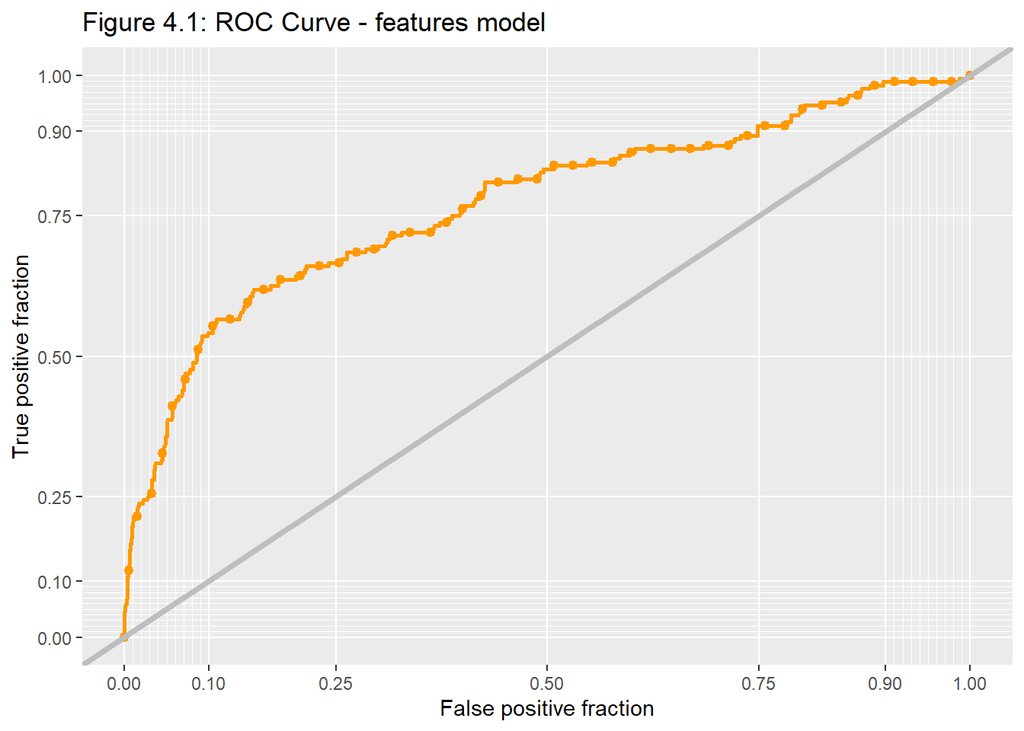

[output not shown]

# Cost benefit analysis

There are four confusion metrics and their cost/benefit equations are presented below.

True Negative - The cost/benefit is 0 in this case, because no credits nor market resources are accepted or allocated.  
True Positive - The cost benefit here should be calculated separately as the following: ((10,000 - 7,850) * (Count * .25)) + ((-2,850) * (Count * .75)). The $2,850 market allocation each is fixed no matter the credit is accepted or not, however, for those who accept the credit, even with an addtional credit cost of $5,000 each, we would still have an $ 10,000 house value premium each adding to the public good.  
False Negative - The cost/benefit is 0, because no credits nor market resources are accepted or allocated through DHC.  
False Positive - The cost/benefit is (-2,850)*Count, because although we are wrong about the prediction, we spend $2,850 each on market allocation already.

The cost/benefit analysis above only applies to individual home and the spillover effect of $56,000 is not included. It’s because $56,000 is just an estimated number, and the spillover effect in reality is highly likely be affected by the size of the neighborhood as well as the distance of the house with its surrounding houses.

The final Cost/Benefit table is shown in table 2. We are expected to lose 62.4k in the True-positive case and 57k in the False-positive case.

```r
cost_benefit_table <-
   testProbs_r2 %>%
      count(predOutcome, Outcome) %>%
      summarize(True_Negative = sum(n[predOutcome==0 & Outcome==0]),
                True_Positive = sum(n[predOutcome==1 & Outcome==1]),
                False_Negative = sum(n[predOutcome==0 & Outcome==1]),
                False_Positive = sum(n[predOutcome==1 & Outcome==0])) %>%
       gather(Variable, Count) %>%
       mutate(Revenue =
               case_when(Variable == "True_Negative"  ~ 0,
                         Variable == "True_Positive"  ~ ((10000 - 7850) * (Count * .25)) + (-2850 * (Count * .75)),   #AD: according to canvas, we can't count the 56000 neighbor premium because we don't know how many neighbors - to only count one neighbor per house is inaccurate
                         Variable == "False_Negative" ~ 0 * Count,
                         Variable == "False_Positive" ~ (-2850)*Count)) %>%
    bind_cols(data.frame(Description = c(
              "Predicted correctly homeowner would not take the credit, no marketing resources were allocated, and no credit was allocated.",
              "Predicted correctly homeowner would take the credit; allocated the marketing resources, and 25% took the credit.",
              "We predicted that a homeowner would not take the credit but they did. These are likely homeowners who signed up for reasons unrelated to the marketing campaign. Thus, we '0 out' this category, assuming the cost/benefit of this is $0.",
              "Predicted incorrectly homeowner would take the credit; allocated marketing resources; no credit allocated."))) %>%
  bind_cols(data.frame(Description = c(
              "Predicted correctly homeowner would not take the credit, no marketing resources were allocated, and no credit was allocated.",
              "Predicted correctly homeowner would take the credit; allocated the marketing resources, and 25% took the credit.",
              "We predicted that a homeowner would not take the credit but they did. These are likely homeowners who signed up for reasons unrelated to the marketing campaign. Thus, we '0 out' this category, assuming the cost/benefit of this is $0.",
              "Predicted incorrectly homeowner would take the credit; allocated marketing resources; no credit allocated.")))

kable(cost_benefit_table, caption = "Table 2: Cost/Benefit Table") %>%
  kable_styling(font_size = 12, full_width = F,
                bootstrap_options = c("striped", "hover", "condensed"))
```

Table 2: Cost/Benefit Table

| Variable | Count | Revenue | Description…4 | Description…5 |
| --- | --- | --- | --- | --- |
| True_Negative | 1242 | 0 | Predicted correctly homeowner would not take the credit, no marketing resources were allocated, and no credit was allocated. | Predicted correctly homeowner would not take the credit, no marketing resources were allocated, and no credit was allocated. |
| True_Positive | 39 | -62400 | Predicted correctly homeowner would take the credit; allocated the marketing resources, and 25% took the credit. | Predicted correctly homeowner would take the credit; allocated the marketing resources, and 25% took the credit. |
| False_Negative | 129 | 0 | We predicted that a homeowner would not take the credit but they did. These are likely homeowners who signed up for reasons unrelated to the marketing campaign. Thus, we ‘0 out’ this category, assumin… | We predicted that a homeowner would not take the credit but they did. These are likely homeowners who signed up for reasons unrelated to the marketing campaign. Thus, we ‘0 out’ this category, assumin… |
| False_Positive | 20 | -57000 | Predicted incorrectly homeowner would take the credit; allocated marketing resources; no credit allocated. | Predicted incorrectly homeowner would take the credit; allocated marketing resources; no credit allocated. |

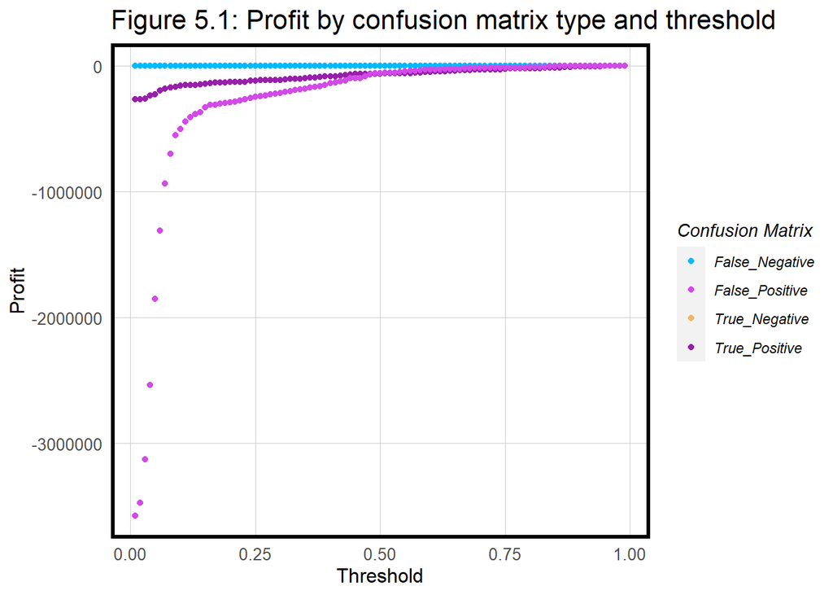

```r
iterateThresholds <- function(data) {
  x = .01
  all_prediction <- data.frame()
  while (x <= 1) {

  this_prediction <-
      testProbs_r2 %>%
      mutate(predOutcome = ifelse(Probs > x, 1, 0)) %>%
      count(predOutcome, Outcome) %>%
      summarize(True_Negative = sum(n[predOutcome==0 & Outcome==0]),
                True_Positive = sum(n[predOutcome==1 & Outcome==1]),
                False_Negative = sum(n[predOutcome==0 & Outcome==1]),
                False_Positive = sum(n[predOutcome==1 & Outcome==0])) %>%
     gather(Variable, Count) %>%
     mutate(Revenue =
               ifelse(Variable == "True_Negative", Count * 0,
               ifelse(Variable == "True_Positive",((10000 - 7850) * (Count * .25)) + (-2850 * (Count * .75)),
               ifelse(Variable == "False_Negative", 0 * Count,
               ifelse(Variable == "False_Positive", (-2850) * Count, 0)))),
            Threshold = x)

  all_prediction <- rbind(all_prediction, this_prediction)
  x <- x + .01
  }
return(all_prediction)
}

whichThreshold <- iterateThresholds(testProbs_r2)

whichThreshold_revenue <-
whichThreshold %>%
    group_by(Threshold) %>%
    summarize(Revenue = sum(Revenue))

#plot
whichThreshold %>%
  ggplot(.,aes(Threshold, Revenue, colour = Variable)) +
  geom_point() +
  scale_colour_manual(values = palette5[c(5, 1:3)]) +
  labs(title = "Figure 5.1: Profit by confusion matrix type and threshold",
       y = "Profit") +
  plotTheme() +
  guides(colour=guide_legend(title = "Confusion Matrix"))
```

```r
whichThreshold_revenue <-
  whichThreshold %>%
    mutate(actualcreditno = ifelse(Variable == "True_Positive", (Count * .75), ifelse(Variable == "False_Positive", Count, 0)),
           actualcredityes = ifelse(Variable == "True_Positive", (Count * .25), ifelse(Variable == "False_Negative", Count, 0))) %>%
    group_by(Threshold) %>%
    summarize(Revenue = sum(Revenue),
              sumcredityes = sum(actualcredityes))


maxrevenueTest <- whichThreshold_revenue[,1:2]

revenue_table <- maxrevenueTest[90:99,]

kable(revenue_table, caption = "Table 3: Total_Revenue and Threshold") %>%
  kable_styling(font_size = 12, full_width = F,
                bootstrap_options = c("striped", "hover"))
```

Table 3: Total_Revenue and Threshold

| Threshold | Revenue |
| --- | --- |
| 0.90 | -4800 |
| 0.91 | -4800 |
| 0.92 | -4800 |
| 0.93 | -3200 |
| 0.94 | -3200 |
| 0.95 | 0 |
| 0.96 | 0 |
| 0.97 | 0 |
| 0.98 | 0 |
| 0.99 | 0 |

Increasing the threshold from 0 to 0.1 has the most significant increase in total revenue and total count of credits. At the threshold of around 0.9, the total revenue and the total count of credits are almost at maximum (Figure 6.1).

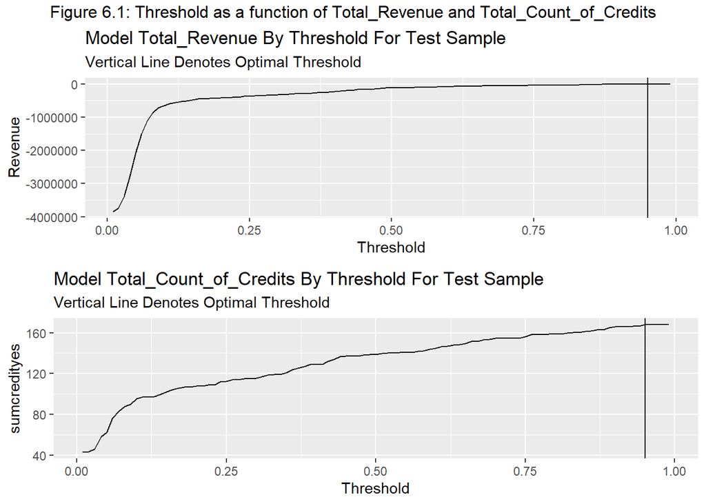

```r
p1<-
  ggplot(whichThreshold_revenue)+
  geom_line(aes(x = Threshold, y = Revenue))+
  geom_vline(xintercept =  pull(arrange(whichThreshold_revenue, -Revenue)[1,1]))+
    labs(title = "Model Total_Revenue By Threshold For Test Sample",
         subtitle = "Vertical Line Denotes Optimal Threshold")

p2<-  ggplot(whichThreshold_revenue)+
  geom_line(aes(x = Threshold, y = sumcredityes))+
  geom_vline(xintercept =  pull(arrange(whichThreshold_revenue, -sumcredityes)[1,1]))+
    labs(title = "Model Total_Count_of_Credits By Threshold For Test Sample",
         subtitle = "Vertical Line Denotes Optimal Threshold")

 grid.arrange(p1, p2, ncol =1, top = "Figure 6.1: Threshold as a function of Total_Revenue and Total_Count_of_Credits")
```

At the threshold of 0.96, we have 168 house owners accepting the credits and the costs of DHC are made even by the increased housing values. That’s to say, the DHC’s efforts are properly rewarded by the growth in housing value and the social good. However at the threshold of 0.5, there are more costs than gains. However, in reality, this threshold can be slightly lower due to the existence of the spillover effect.

```r
threshold_table <- whichThreshold_revenue[c(50, 96), c("Threshold", "Revenue", "sumcredityes")]

threshold_table %>%
  group_by(Threshold) %>%
  kable(caption = "Table 4: Total_Revenue and Total_Count_of_Credits by threshold", col.names = c("Threshold", "Total revenue", "Total count of credits")) %>%
    kable_styling("striped", full_width = T)
```

Table 4: Total_Revenue and Total_Count_of_Credits by threshold

| Threshold | Total revenue | Total count of credits |
| --- | --- | --- |
| 0.50 | -119400 | 138.75 |
| 0.96 | 0 | 168.00 |

# Conclusions

This model with new features should be put into production because it has a better classification performance, and higher accuracy in predicting both house owners accepting and refusing tax credits compared to the kitchen-sink model. The new threshold (0.96) makes possible that the costs of DHC are properly rewarded by the gains in housing value premium. More tax revenue can be generated from this process and be put into producing more public good.

Lastly, to make sure that the marketing materials have a better response rate, we can reset a higher threshold while improving our model’s sensitivity at the same time. The response rate is supposed to climb as our prediction power goes up.